# Linear Regression Analysis of Kickstarters

CS 510 - Lindsay Waldrop

Joshua Anderson

## Goal

The goal of the analysis is to determine how to best predict the money pledged to a given kickstarter using various linear methods. Comparing an ordinary linear model, boostrapped linear model, and bayesian linear model, I evaluate several different metrics to determine which method provided the most accurate result. The final draft of the analysis is stored in the [**final.Rmd**](https://github.com/ander428/CS-510-Midterm/blob/main/final.Rmd) file. The midterm_first_draft.R, and midterm_complete.R files are stored to document the project before initial feedback.

## Data

This project is for Computing for Scientists (CS 510) at Chapman University. The dataset used is [kickstarters over the course of 2018](https://www.kaggle.com/kemical/kickstarter-projects) containing various information about the kickstarters’ goals, category, etc. Here is a brief data dictionary:

- **Name**: name of the kickstarter
- **Category**": a specific/narrow category the kickstarter falls under
- **Main Category**: the most general category that the kickstarter falls under
- **deadline**: the deadline date to meet the kickstarter goal
- **state**: results of the kickstarter, i.e., whether it met its goal or not
- **backers**: number of people who have contributed
- **Currency**: currency used by backers to fund kickstarter
- **Country**: the country where the kickstarter is based
- **usd pledge real**: conversion of pledged in US dollars of the pledged column (conversion from Fixer.io API).
- **usd goal real**: conversion in US dollars of the goal column (conversion from Fixer.io API).

## Analysis

### Data Cleaning

The data was well put together from the start so there was not an extensive amount of data cleaning required. The two major transformations included the following: creating a length for the Kickstarter campaigns and limiting the variables to numeric. This changed the dimensions of the dataset from 378661 x 15 to 378661 x 4 for the cleaned dataset.

The variables left include the following: backers, usd_pledged_real, usd_goal_real, and length

### Exploratory Analysis of the Data

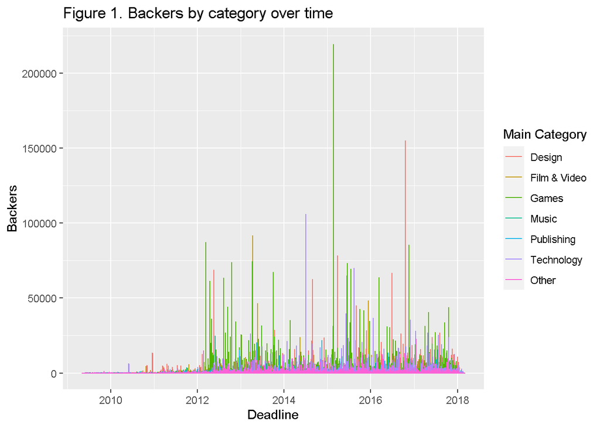

*Figure 1 shows the most backed Kickstarters over time by category. It should be noted that Games, Technology, and Design stood out compared other categories. This is likely due to a combination of uneven distribution between categories as well as higher goals in those categories.*

[figure not shown]

### Modeling

There were three different models used. Each is listed below.

**Ordinary Linear Regression (OLS)**: This was coded from scratch using the following formula:
$$Betas = (X^TX)^{-1} \cdot X^Ty$$
. This generates the coefficients of the linear model.

**Bootstrapped OLS**: This used the OLS algorithm within a bootstrap. Both the mean and median aggregate coefficients were evaluated.

**Bayesian Linear Regression**: This was taken from the *rstanarm* package. The formula for this type of regression is a little more involved. Given $x_i$ is the set of features in a given row, there is a weight, $w_i$ that measures the importance of a variable. $S_0$ is the covariance matrix. The formula can be shown as:

$$p(y_i) = N(\mu_i, \sigma_i),\ where\ \mu_i=w_ix_{i}^T\ and\ \sigma_i=\frac{1}{\beta}+x_iS_ix_i^T$$

### Results

There were three diagnostic metrics to look at: RMSE, MAE, and R-squared. They can be viewed by this plot.

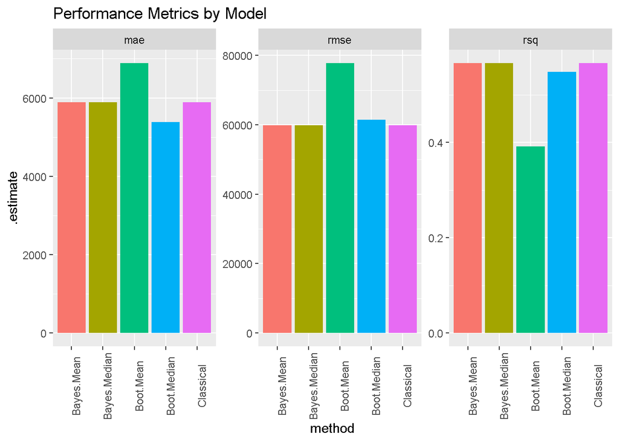